Skip to main content

# Lollipop

Python

code

Visualization

Author

Marco Aguirre

Published

September 29, 2025

Un **gráfico de piruleta (Lollipop chart)** es una variación del gráfico de barras en el que cada barra se sustituye por una **línea delgada** que termina en un **punto**. Al igual que el gráfico de barras, permite mostrar la relación entre una **variable categórica** y una **numérica**, pero con una apariencia más ligera y atractiva. Su simplicidad visual ayuda a **evitar la sobrecarga gráfica** cuando existen muchas categorías o valores muy similares.

Este tipo de gráfico resulta especialmente útil cuando se busca destacar **diferencias sutiles** entre categorías o cuando varias tienen valores cercanos, reduciendo el “efecto Moiré” que puede aparecer en un barplot clásico.

Para mejorar su claridad, conviene:  
- **Ordenar los grupos** (idealmente de mayor a menor si no existe un orden natural).  
- Usar la **versión horizontal** cuando las etiquetas son extensas, para mejorar la lectura.  
- Resaltar los puntos con colores adecuados que faciliten la comparación.  
- Usarlo cuando solo se represente **un valor por categoría**, sin subgrupos múltiples.

### Errores habituales:

- No ordenar las categorías: dificulta la lectura y comprensión.
- Usarlo con **varios valores por grupo**: en ese caso es preferible un boxplot o violin plot.
- Mantener los datos sin orden natural en lollipop puede confundir: en esas situaciones un barplot es más claro.
- Forzar el uso cuando se necesita mostrar **distribuciones completas**; el lollipop solo muestra un valor central.

# Dataset: Precios Agroindustria de Cacao (2012 - 2025)

**Archivo:** `MAG_PreciosAgroindustriaCacao_2025Junio.csv`  
**Fuente:** Ministerio de Agricultura y Ganadería (MAG), Ecuador  
**Última actualización:** Junio 2025

```python
import pandas as pd
df = pd.read_csv("mag_preciosagroindustriacacao_2025junio.csv", sep=";")
print(df.head())
print(df.info())
```

```
   PACC_ANIO PACC_MES DPA_PROVINCIA DPA_CANTON        PACC_PRODUCTO  \
0       2012    Enero        El Oro  Arenillas  Cacao seco mezclado
1       2012    Enero        El Oro  Arenillas  Cacao seco mezclado
2       2012    Enero        El Oro   El Guabo  Cacao seco mezclado
3       2012    Enero        El Oro   El Guabo  Cacao seco mezclado
4       2012    Enero        El Oro    Machala  Cacao seco mezclado

          PACC_PRESENTACION PACC_TIPO  PACC_PRECIO_USD  PACC_USD_KG
0  Quintal de 100,00 libras    Compra            71.41         1.57
1  Quintal de 100,00 libras     Venta            74.06         1.63
2  Quintal de 100,00 libras    Compra            73.75         1.63
3  Quintal de 100,00 libras     Venta            84.00         1.85
4  Quintal de 100,00 libras    Compra            75.00         1.65
<class 'pandas.core.frame.DataFrame'>
RangeIndex: 26246 entries, 0 to 26245
Data columns (total 9 columns):
 #   Column             Non-Null Count  Dtype
---  ------             --------------  -----
 0   PACC_ANIO          26246 non-null  int64
 1   PACC_MES           26246 non-null  object
 2   DPA_PROVINCIA      26246 non-null  object
 3   DPA_CANTON         26246 non-null  object
 4   PACC_PRODUCTO      26246 non-null  object
 5   PACC_PRESENTACION  26246 non-null  object
 6   PACC_TIPO          26246 non-null  object
 7   PACC_PRECIO_USD    26246 non-null  float64
 8   PACC_USD_KG        26246 non-null  float64
dtypes: float64(2), int64(1), object(6)
memory usage: 1.8+ MB
None
```

```python
import plotly.graph_objects as go
import plotly.io as pio
pio.renderers.default = "notebook"
```

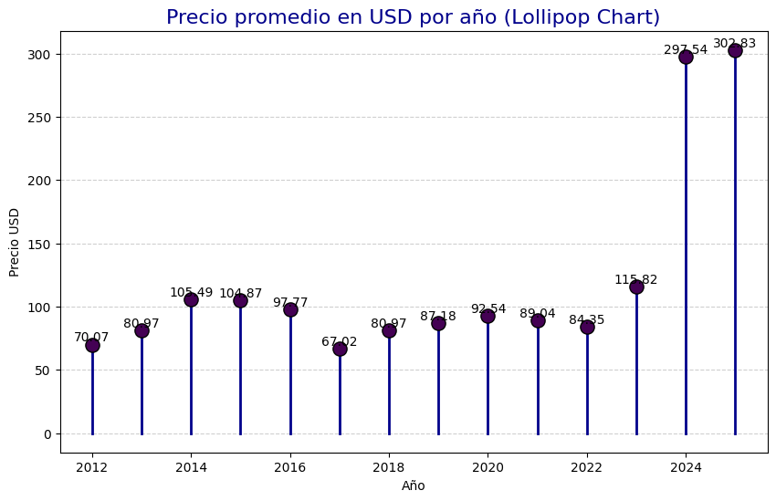

```python
import matplotlib.pyplot as plt

# Agrupar para obtener el precio promedio por año
df_avg_anio = df.groupby("PACC_ANIO", as_index=False)["PACC_PRECIO_USD"].mean()

# Datos
x = df_avg_anio["PACC_ANIO"]
y = df_avg_anio["PACC_PRECIO_USD"]

# Crear figura
plt.figure(figsize=(10, 6))

# Dibujar líneas desde 0 hasta cada valor (tallo del lollipop)
for i in range(len(x)):
    plt.plot([x[i], x[i]], [0, y[i]], color="darkblue", linewidth=2)
    plt.scatter(x[i], y[i],
                c=y[i], cmap="viridis",
                s=120, edgecolor="black", zorder=3)

    # Texto encima de cada punto
    plt.text(x[i], y[i] + 0.5, f"{y[i]:.2f}",
             ha="center", va="bottom", fontsize=10)

# Estilo general
plt.title("Precio promedio en USD por año (Lollipop Chart)", fontsize=16, color="darkblue")
plt.xlabel("Año")
plt.ylabel("Precio USD")
plt.grid(axis="y", linestyle="--", alpha=0.6)
plt.gca().set_facecolor("white")

plt.show()
```

```python
import numpy as np
import plotly.graph_objs as go
import plotly.offline as pyo

def plotly_lollipop(signal, orientation="vertical",
                    marker_color="red", line_color="grey",
                    marker_offset=0.04, title="Lollipop Chart"):
    """
    Genera un gráfico tipo Lollipop (vertical u horizontal) con Plotly.

    Parámetros
    ----------
    signal : list, np.array o pd.Series
        Señal de valores numéricos a graficar.
    orientation : str
        'vertical' para palitos en eje Y (default), 'horizontal' para palitos en eje X.
    marker_color : str
        Color de los puntos (default = 'red').
    line_color : str
        Color de las líneas (default = 'grey').
    marker_offset : float
        Margen de separación entre la línea y el punto para evitar superposición.
    title : str
        Título del gráfico.
    """

    def offset_signal(val, marker_offset):
        if abs(val) <= marker_offset:
            return 0
        return val - marker_offset if val > 0 else val + marker_offset

    n = len(signal)

    # Puntos
    if orientation == "vertical":
        data = [go.Scatter(
            x=list(range(n)),
            y=signal,
            mode="markers",
            marker=dict(color=marker_color, size=8)
        )]
        shapes = [dict(
            type="line",
            xref="x",
            yref="y",
            x0=i, y0=0,
            x1=i, y1=offset_signal(signal[i], marker_offset),
            line=dict(color=line_color, width=1)
        ) for i in range(n)]

    elif orientation == "horizontal":
        data = [go.Scatter(
            x=signal,
            y=list(range(n)),
            mode="markers",
            marker=dict(color=marker_color, size=8)
        )]
        shapes = [dict(
            type="line",
            xref="x",
            yref="y",
            x0=0, y0=i,
            x1=offset_signal(signal[i], marker_offset), y1=i,
            line=dict(color=line_color, width=1)
        ) for i in range(n)]

    else:
        raise ValueError("orientation debe ser 'vertical' o 'horizontal'")

    # Layout
    layout = go.Layout(shapes=shapes, title=title)
    fig = go.Figure(data=data, layout=layout)
    pyo.iplot(fig)
    return fig


# Ejemplo de uso
if __name__ == "__main__":
    np.random.seed(42)
    random_signal = np.random.normal(size=20)

    # Vertical
    plotly_lollipop(random_signal, orientation="vertical", marker_color="blue", line_color="black", title="Lollipop Vertical")

    # Horizontal
    plotly_lollipop(random_signal, orientation="horizontal", marker_color="green", line_color="black", title="Lollipop Horizontal")
```

[interactive chart not shown]

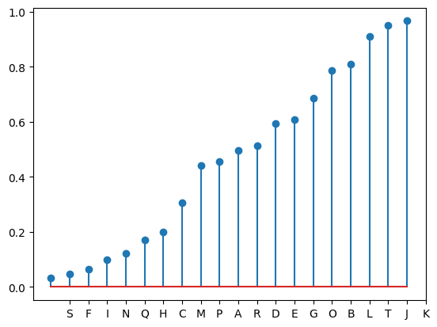

```python
# Create a dataframe
import pandas as pd
df = pd.DataFrame({'group':list(map(chr, range(65, 85))), 'values':np.random.uniform(size=20) })

# Reorder it following the values:
ordered_df = df.sort_values(by='values')
my_range=range(1,len(df.index)+1)

# Make the plot
plt.stem(ordered_df['values'])
plt.xticks( my_range, ordered_df['group'])
```

```python
# --- Usamos la función definida antes ---
import plotly.graph_objs as go
import plotly.offline as pyo

def plotly_lollipop(x, y, orientation="vertical",
                    marker_color="red", line_color="grey",
                    marker_offset=0.04, title="Lollipop Chart"):
    """
    Genera un gráfico tipo Lollipop (vertical u horizontal) con Plotly.
    """
    def offset_signal(val, marker_offset):
        if abs(val) <= marker_offset:
            return 0
        return val - marker_offset if val > 0 else val + marker_offset

    n = len(y)

    if orientation == "vertical":
        data = [go.Scatter(
            x=x,
            y=y,
            mode="markers",
            marker=dict(color=marker_color, size=8)
        )]
        shapes = [dict(
            type="line",
            xref="x",
            yref="y",
            x0=x[i], y0=0,
            x1=x[i], y1=offset_signal(y[i], marker_offset),
            line=dict(color=line_color, width=1)
        ) for i in range(n)]

    elif orientation == "horizontal":
        data = [go.Scatter(
            x=y,
            y=x,
            mode="markers",
            marker=dict(color=marker_color, size=8)
        )]
        shapes = [dict(
            type="line",
            xref="x",
            yref="y",
            x0=0, y0=x[i],
            x1=offset_signal(y[i], marker_offset), y1=x[i],
            line=dict(color=line_color, width=1)
        ) for i in range(n)]

    else:
        raise ValueError("orientation debe ser 'vertical' o 'horizontal'")

    layout = go.Layout(
        shapes=shapes,
        title=title,
        xaxis=dict(title="Año" if orientation=="vertical" else "Precio USD"),
        yaxis=dict(title="Precio USD" if orientation=="vertical" else "Año")
    )

    fig = go.Figure(data=data, layout=layout)
    pyo.iplot(fig)
    return fig


# --- Aplicación a tu dataset ---
x = df_avg_anio["PACC_ANIO"]
y = df_avg_anio["PACC_PRECIO_USD"]

# Vertical
plotly_lollipop(x, y, orientation="vertical", marker_color="blue", line_color="black", title="Precio promedio en USD por año")

# Horizontal (opcional)
# plotly_lollipop(x, y, orientation="horizontal", marker_color="green", line_color="black", title="Precio promedio en USD por año (horizontal)")
```

[interactive chart not shown]